# Keyword Spotting System Deployment on AWS

In this project we build a keyword spotting system and we deploy it to an **Amazon AWS EC2**, instance using **Docker**, **Flask**, **TensorFlow**, **uWSGI** and **NGiNX**.

The dataset that we are going to use, can be found on [Google AI Blog](https://ai.googleblog.com/2017/08/launching-speech-commands-dataset.html).

The GitHub repository of this project can be found [here](https://github.com/nicksento/Keyword-Spotting-System-Deployment-on-AWS).

# Contents

1.The System Architecture  
2.Prepare the Keyword Dataset  
3.Build-and-Train-a-Convolutional-Neural-Network  
4.Making Predictions  
5.Flask API  
6.Client  
7.Adding uWSGI  
8.Adding NGiNX'  
9.Dockerfile for Flask  
10.Dockerfile for NGiNX  
11.Docker Compose  
12.Deploying the Keyword Spotting System on Amazon AWS

# The System Architecture

A Keyword Spotting System is a system which is able to identify a limited number of keywords and it is being used for Voice User Interfaces.

The system architecture is presented below.

[figure not shown]

The Web Server Gateway Interface (**WSGI**) is a simple calling convention for web servers to forward requests to web applications or frameworks written in the Python programming language.

We will also use **Docker** and specifically we are going to build two *Docker containers* one for **NGiNX** and one for **uWSGI**, **Flask** and **TensorFlow**.

**Docker Container** is a standalone software package that has all the libraries to run an application.

**Docker Containers** are cross-platform so the moment you have built one, is going to work on Linux, on Windows and on Mac no matter the type of machine you have.

Our application is a multi containter application so, in order to orchestrate different containers together, we are going to use **Docker Compose** which enables us to build a network of containers which allows different containers talking to each other.

# Prepare the Keyword Dataset

One way to classify data is through neural networks. Because NNs usually take in some sort of image representation, we will extract the Mel-frequency cepstral coefficients (MFCCs) from the audio files .

In sound processing, the mel-frequency cepstrum (MFC) is a representation of the shortterm power spectrum of a sound, based on a linear cosine transform of a log power spectrum on a nonlinear mel scale of frequency.

Mel-frequency cepstral coefficients (MFCCs) are coefficients that collectively make up an MFC. They are derived from a type of cepstral representation of the audio clip (a nonlinear "spectrum-of-a-spectrum"). The difference between the cepstrum and the mel-frequency cepstrum is that in the MFC, the frequency bands are equally spaced on the mel scale, which approximates the human auditory system's response more closely than the linearly-spaced frequency bands used in the normal cepstrum. This frequency warping can allow for better representation of sound, for example, in audio compression.

MFCCs are commonly derived as follows:

1. Take the Fourier transform of (a windowed excerpt of) a signal.
2. Map the powers of the spectrum obtained above onto the mel scale, using triangular overlapping windows.
3. Take the logs of the powers at each of the mel frequencies.
4. Take the discrete cosine transform of the list of mel log powers, as if it were a signal.
5. The MFCCs are the amplitudes of the resulting spectrum.

[output not shown]

```
import librosa
import os
import json

DATASET_PATH = "dataset"
JSON_PATH = "data.json"
SAMPLES_TO_CONSIDER = 22050

def prepare_dataset(dataset_path, json_path, n_mfcc=13, hop_length=512, n_fft=2048):

    # data dictionary
    data = {
        "mappings": [],
        "labels": [],
        "MFCCs": [],
        "files": []
    }

    # loop through all the sub-dirs
    for i, (dirpath, dirnames, filenames) in enumerate(os.walk(dataset_path)):

        # we need to ensure that we're not at root level
        if dirpath is not dataset_path:

            # update mappings
            category = dirpath.split("/")[-1]
            data["mappings"].append(category)
            print(f"Processing {category}")

            # loop through all the filenames and extract MFCCs
            for f in filenames:

                # get file path
                file_path = os.path.join(dirpath, f)

                # load audio file
                signal, sr = librosa.load(file_path)

                # ensure the audio file is at least 1 sec
                if len(signal) >= SAMPLES_TO_CONSIDER:

                    # enforce 1 sec. long signal
                    signal = signal[:SAMPLES_TO_CONSIDER]


                    # extract the MFCCs
                    MFCCs = librosa.feature.mfcc(signal, n_mfcc=n_mfcc,
                                                 hop_length=hop_length,
                                                 n_fft=n_fft)

                    # store data
                    data["labels"].append(i-1)
                    data["MFCCs"].append(MFCCs.T.tolist())
                    data["files"].append(file_path)
                    print(f"{file_path}: {i-1}")


    # store in json file
    with open(json_path, "w") as fp:
        json.dump(data, fp, indent=4)

if __name__ == "__main__":
    prepare_dataset(DATASET_PATH, JSON_PATH)
```

# Build and Train a Convolutional Neural Network

In deep learning, a convolutional neural network (CNN, or ConvNet) is a class of deep neural networks, most commonly applied to analyzing visual imagery.They have applications in image and video recognition, recommender systems, image classification, image segmentation, medical image analysis, natural language processing, brain-computer interfaces, and financial time series.

CNNs are regularized versions of multilayer perceptrons. Multilayer perceptrons usually mean fully connected networks, that is, each neuron in one layer is connected to all neurons in the next layer. The "full connectivity" of these networks make them prone to overfitting data. Typical ways of regularization, or preventing overfitting, include: penalizing parameters during training (such as weight decay) or trimming connectivity (skipped connections, dropout, etc.) CNNs take a different approach towards regularization: they take advantage of the hierarchical pattern in data and assemble patterns of increasing complexity using smaller and simpler patterns embossed in their filters. Therefore, on a scale of connectivity and complexity, CNNs are on the lower extreme.

CNNs use relatively little pre-processing compared to other image classification algorithms. This means that the network learns to optimize the filters (or kernels) through automated learning, whereas in traditional algorithms these filters are hand-engineered. This independence from prior knowledge and human intervention in feature extraction is a major advantage.

```
import json
import numpy as np
import tensorflow as tf
from sklearn.model_selection import train_test_split

DATA_PATH = "data.json"
SAVED_MODEL_PATH = "model.h5"

LEARNING_RATE = 0.0001
EPOCHS = 40
BATCH_SIZE = 32

NUM_KEYWORDS = 10

def load_dataset(data_path):

    with open(data_path, "r") as fp:
        data = json.load(fp)

    # extract inputs and targets
    X = np.array(data["MFCCs"])
    y = np.array(data["labels"])

    return X, y

def get_data_splits(data_path, test_size=0.1, validation_size=0.1):

    # load dataset
    X, y = load_dataset(data_path)

    # create train/validation/test splits
    X_train, X_test, y_train, y_test = train_test_split(X, y, test_size=test_size)
    X_train, X_validation, y_train, y_validation = train_test_split(X_train, y_train,
                                                                   test_size=validation_size)

    # convert inputs from 2d to 3d arrays
    X_train = X_train[..., np.newaxis]
    X_validation = X_validation[..., np.newaxis]
    X_test = X_test[..., np.newaxis]

    return X_train, X_validation, X_test, y_train, y_validation, y_test

def build_model(input_shape, learning_rate, error="sparse_categorical_crossentropy"):

    # build the network
    model = tf.keras.Sequential()

    # conv layer 1
    model.add(tf.keras.layers.Conv2D(64, (3,3), activation="relu",
                                 input_shape=input_shape,
                                 kernel_regularizer=tf.keras.regularizers.l2(0.001)))

    model.add(tf.keras.layers.BatchNormalization())
    model.add(tf.keras.layers.MaxPool2D((3,3), strides=(2,2), padding="same"))

    # conv layer 2
    model.add(tf.keras.layers.Conv2D(32, (3,3), activation="relu",
                                 kernel_regularizer=tf.keras.regularizers.l2(0.001)))
    model.add(tf.keras.layers.BatchNormalization())
    model.add(tf.keras.layers.MaxPool2D((3,3), strides=(2,2), padding="same"))
    # conv layer 3
    model.add(tf.keras.layers.Conv2D(32, (2,2), activation="relu",
                                 kernel_regularizer=tf.keras.regularizers.l2(0.001)))
    model.add(tf.keras.layers.BatchNormalization())
    model.add(tf.keras.layers.MaxPool2D((2,2), strides=(2,2), padding="same"))

    # flatten the output feed it into a dense layer
    model.add(tf.keras.layers.Flatten())
    model.add(tf.keras.layers.Dense(64, activation="relu"))
    model.add(tf.keras.layers.Dropout(0.3))

    # softmax classifier
    model.add(tf.keras.layers.Dense(NUM_KEYWORDS, activation="softmax"))

    # compile the model
    optimiser = tf.keras.optimizers.Adam(learning_rate=learning_rate)
    model.compile(optimizer=optimiser, loss=error, metrics=["accuracy"])

    # print model overview
    model.summary()

    return model

def main():

    # load train/validation/test data splits
    X_train, X_validation, X_test, y_train, y_validation, y_test = get_data_splits(DATA_PATH)


    # build the CNN model
    input_shape = (X_train.shape[1], X_train.shape[2], X_train.shape[3])
                 #(# segments, # coefficients 13, 1)
    model = build_model(input_shape, LEARNING_RATE)


    # train the model
    model.fit(X_train, y_train, epochs=EPOCHS, batch_size=BATCH_SIZE,
                          validation_data=(X_validation, y_validation))

    # evaluate the model
    test_error, test_accuracy = model.evaluate(X_test, y_test)
    print(f"Test error: {test_error}, Test accuracy: {test_accuracy}")


    # save the model
    model.save(SAVED_MODEL_PATH)

if __name__ == "__main__":
    main()
```

[figure not shown]

# Making Predictions

```
import tensorflow.keras as keras
import numpy as np
import librosa

MODEL_PATH = "model.h5"

NUM_SAMPLES_TO_CONSIDER = 22050 # 1 sec

class _Keyword_Spotting_Service:

    model = None
    _mapping = [
        "on",
        "left",
        "down",
        "go",
        "no",
        "right",
        "stop",
        "yes",
        "up",
        "off"
    ]
    _instance = None

    def predict(self, file_path):

        # exctract MFCCs
        MFCCs = self.preprocess(file_path)

        # convert 2d MFCCs array into 4d array -> (# samples, # segments, # coefficients, # 1)
        MFCCs = MFCCs[np.newaxis, ..., np.newaxis]
        # make prediction
        predictions = self.model.predict(MFCCs) # [[10 different values for scores]]
        predicted_index = np.argmax(predictions)
        predicted_keyword = self._mapping[predicted_index]

        return predicted_keyword

    def preprocess(self, file_path, n_mfcc=13, n_fft=2048, hop_length=512):

        # load audio file
        signal, sr = librosa.load(file_path)

        # ensure consistency in the audio file length
        if len(signal) > NUM_SAMPLES_TO_CONSIDER:
            signal = signal[:NUM_SAMPLES_TO_CONSIDER]
        if len(signal) < NUM_SAMPLES_TO_CONSIDER:
            signal = np.pad(signal, (0, NUM_SAMPLES_TO_CONSIDER-signal.shape[0]),
                            'constant', constant_values=0)


        # exteact MFCCs
        MFCCs = librosa.feature.mfcc(signal, n_mfcc=n_mfcc,
                                     n_fft=n_fft, hop_length=hop_length)

        return MFCCs.T

def Keyword_Spotting_Service():
    # ensure that we only have 1 instance of KSS
    if _Keyword_Spotting_Service._instance is None:
        _Keyword_Spotting_Service._instance = _Keyword_Spotting_Service()
        _Keyword_Spotting_Service.model = keras.models.load_model(MODEL_PATH)
    return _Keyword_Spotting_Service._instance

if __name__ == "__main__":

    # create 2 instances of the keyword spotting service
    kss = Keyword_Spotting_Service()
    kss1 = Keyword_Spotting_Service()

    # check that different instances of the keyword spotting service point back to the same object (singleton)
    assert kss is kss1

    # make a prediction
    #keyword = kss.predict("test/down.wav")
    keyword = kss.predict('test/down.wav')
    print(keyword)
```

# Flask API

```
import random
import os
from flask import Flask, request, jsonify
from keyword_spotting_service import Keyword_Spotting_Service

app = Flask(__name__)

@app.route("/predict", methods=["POST"])
def predict():

    # get audio file and save it
    audio_file = request.files["file"]
    file_name = str(random.randint(0, 100000))
    audio_file.save(file_name)

    # invoke keyword spotting service
    kss = Keyword_Spotting_Service()

    # make a prediction
    predicted_keyword = kss.predict(file_name)

    # remove the audio file
    os.remove(file_name)

    # send back the predicted keyword in json format
    data = {"keyword": predicted_keyword}
    return jsonify(data)


if __name__ == "__main__":
    app.run(debug=False)
```

# Client

```
import requests

URL = "http://public/ip/of/aws/instance/predict"
TEST_AUDIO_FILE_PATH = "test/down.wav"

if __name__ == "__main__":

    audio_file = open(TEST_AUDIO_FILE_PATH, "rb")
    values = {"file": (TEST_AUDIO_FILE_PATH, audio_file, "audio/wav")}
    response = requests.post(URL, files=values)
    data = response.json()

    print(f"Predicted keyword is: {data['keyword']}")
```

# Adding uWSGI

```
[uwsgi]

socket = :900
wsgi-file = server.py
callable = app
processes = 1
threads = 1
master = true
```

# Adding NGiNX

```
server {
    listen 1234;
    client_body_buffer_size 5M;
    client_max_body_size 5M;

    location / {
        include uwsgi_params;
        uwsgi_pass flask:900;
    }
}
```

# Dockerfile for Flask

```
# Pull tensorflow image with Python3
FROM tensorflow/tensorflow:2.1.0-py3

# Set the working directory to /app
WORKDIR /app

# Transfer content from current dir to /app in container
ADD . /app

# Install audio libraries
RUN apt-get update && apt-get install -y libsndfile1 libasound-dev portaudio19-dev libportaudio2 libportaudiocpp0 ffmpeg

# Install python packages
RUN pip install -r requirements.txt

# Start uWSGI using config file
CMD ["uwsgi", "app.ini"]
```

# Dockerfile for NGiNX

```
# Pull nginx image from Docker Hub
FROM nginx

# Remove the default nginx config file and replace it with the new one
RUN rm /etc/nginx/conf.d/default.conf
COPY nginx.conf /etc/nginx/conf.d/
```

# Docker Compose

```
version: "3.7"

services:

  flask:
    build: ./flask
    container_name: flask
    restart: always
    expose:
      - 900

  nginx:
    build: ./nginx
    container_name: nginx
    restart: always
    ports:
      - "80:1234"
```

# Deploying the Keyword Spotting System on Amazon AWS

Our system is deployed and built successfully on an EC2 instance on Amazon AWS.

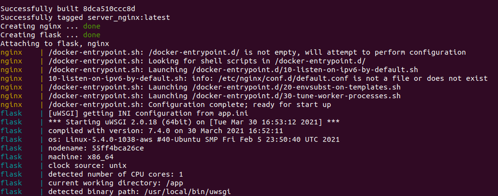

As we can see, it received our post request and send us back the prediction.

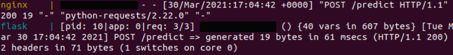